# 兆易创新（603986.SH）技术指标分析实验室

## TASK2 — 技术指标计算与信号回测

| 项目 | 内容 |
| --- | --- |
| 分析对象 | 兆易创新 603986.SH |
| 数据区间 | 2025-07-01 至 2026-07-01（243 个交易日） |
| 指标覆盖 | MACD、BB（布林带）、RSI、ATR |
| 信号回测 | MACD 金叉/死叉、RSI 超买/超卖 |

> **颜色规范**：遵循 A 股惯例 —— 红色=涨，绿色=跌

```python
import pandas as pd
import numpy as np
import matplotlib.pyplot as plt
import matplotlib.dates as mdates

# matplotlib 中文字体配置
%matplotlib inline
plt.rcParams['font.sans-serif'] = ['SimHei', 'Microsoft YaHei', 'DejaVu Sans']
plt.rcParams['axes.unicode_minus'] = False
plt.rcParams['figure.dpi'] = 150

# 颜色常量（A 股规范: 红涨绿跌）
RED    = '#e74c3c'
GREEN  = '#27ae60'
BLUE   = '#3498db'
ORANGE = '#f39c12'
PURPLE = '#9b59b6'
DARK   = '#1a1a2e'

print('环境配置完成')
print(f'pandas: {pd.__version__}, numpy: {np.__version__}')
```

```
环境配置完成
pandas: 3.0.3, numpy: 2.5.0
```

## 1. 数据加载

从 `../data/603986_daily.csv` 读取兆易创新日线数据，包含 open/high/low/close/vol 等字段。

```python
# 数据加载
df = pd.read_csv('../data/603986_daily.csv', encoding='utf-8')
df['trade_date'] = pd.to_datetime(df['trade_date'])
df = df.sort_values('trade_date').reset_index(drop=True)
df.set_index('trade_date', inplace=True)

print(f'数据形状: {df.shape}')
print(f'时间范围: {df.index[0].date()} ~ {df.index[-1].date()}')
df.head(10)
```

```
数据形状: (243, 9)
时间范围: 2025-07-01 ~ 2026-07-01
```

| trade_date | open | high | low | close | pre_close | change | pct_chg | vol | amount |
| --- | --- | --- | --- | --- | --- | --- | --- | --- | --- |
| 2025-07-01 | 126.00 | 126.55 | 123.51 | 124.02 | 126.53 | -2.51 | -1.98 | 142875.87 | 1.771947e+09 |
| 2025-07-02 | 123.28 | 123.30 | 120.10 | 120.98 | 124.02 | -3.04 | -2.45 | 130681.06 | 1.580979e+09 |
| 2025-07-03 | 120.58 | 121.55 | 119.00 | 119.72 | 120.64 | -0.92 | -0.76 | 128590.07 | 1.539480e+09 |
| 2025-07-04 | 119.19 | 120.30 | 117.51 | 118.85 | 119.72 | -0.87 | -0.73 | 141826.95 | 1.685613e+09 |
| 2025-07-07 | 118.98 | 120.81 | 117.86 | 120.81 | 118.85 | 1.96 | 1.65 | 114584.95 | 1.384301e+09 |
| 2025-07-08 | 123.00 | 123.50 | 121.01 | 121.71 | 120.82 | 0.89 | 0.74 | 151877.86 | 1.848505e+09 |
| 2025-07-09 | 120.91 | 120.99 | 119.29 | 119.47 | 121.71 | -2.24 | -1.84 | 126056.42 | 1.505996e+09 |
| 2025-07-10 | 119.02 | 119.87 | 118.04 | 118.06 | 119.47 | -1.41 | -1.18 | 111583.31 | 1.317353e+09 |
| 2025-07-11 | 117.90 | 119.10 | 117.37 | 118.36 | 118.06 | 0.30 | 0.25 | 129774.02 | 1.536005e+09 |
| 2025-07-14 | 118.61 | 119.20 | 117.46 | 117.59 | 118.36 | -0.77 | -0.65 | 112791.53 | 1.326316e+09 |

```python
# 数据概览统计
df.describe().round(2)
```

|  | open | high | low | close | pre_close | change | pct_chg | vol | amount |
| --- | --- | --- | --- | --- | --- | --- | --- | --- | --- |
| count | 243.00 | 243.00 | 243.00 | 243.00 | 243.00 | 243.00 | 243.00 | 243.00 | 2.430000e+02 |
| mean | 264.34 | 273.40 | 257.72 | 266.42 | 263.76 | 2.66 | 0.84 | 373692.03 | 1.085550e+10 |
| std | 133.14 | 140.55 | 128.25 | 136.88 | 133.23 | 15.53 | 4.28 | 154533.48 | 8.757061e+09 |
| min | 114.05 | 116.40 | 113.82 | 114.24 | 114.24 | -48.69 | -10.00 | 111583.31 | 1.317353e+09 |
| 25% | 189.20 | 197.44 | 186.52 | 190.75 | 190.42 | -5.06 | -2.21 | 253999.22 | 5.542045e+09 |
| 50% | 230.00 | 234.68 | 222.50 | 230.10 | 227.92 | 0.90 | 0.42 | 364021.47 | 8.572750e+09 |
| 75% | 300.00 | 309.29 | 291.68 | 300.74 | 298.85 | 7.10 | 3.26 | 464717.58 | 1.269807e+10 |
| max | 810.00 | 846.66 | 781.11 | 840.00 | 840.03 | 70.09 | 10.00 | 858971.49 | 4.546154e+10 |

```
findfont: Failed to find font weight bold, now using 400.
```

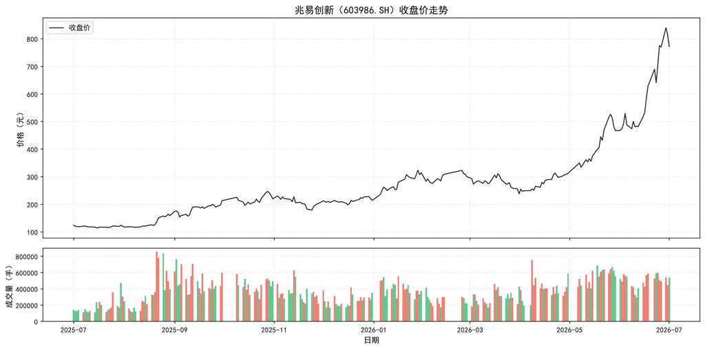

```
区间累计涨幅: 522.5%
```

```python
# 数据概览图：收盘价 + 成交量
fig, (ax1, ax2) = plt.subplots(2, 1, figsize=(14, 7), gridspec_kw={'height_ratios': [3, 1]}, sharex=True)

# 收盘价
ax1.plot(df.index, df['close'], color=DARK, linewidth=1.2, label='收盘价')
ax1.set_title('兆易创新（603986.SH）收盘价走势', fontsize=14, fontweight='bold')
ax1.set_ylabel('价格（元）', fontsize=11)
ax1.legend(loc='upper left', fontsize=10)
ax1.grid(True, alpha=0.25, linestyle='--')

# 成交量（红涨绿跌）
colors = [RED if c >= o else GREEN for c, o in zip(df['close'], df['open'])]
ax2.bar(df.index, df['vol'], color=colors, width=1, alpha=0.7)
ax2.set_ylabel('成交量（手）', fontsize=11)
ax2.set_xlabel('日期', fontsize=11)
ax2.grid(True, alpha=0.25, linestyle='--')

plt.tight_layout()
plt.show()

print(f'区间累计涨幅: {((df["close"].iloc[-1] / df["close"].iloc[0]) - 1) * 100:.1f}%')
```

## 2. MACD（指数平滑异同移动平均线）

MACD 是趋势类指标的核心，利用快速（12日）与慢速（26日）EMA 的差值判断趋势方向与动能变化。

| 要素 | 说明 |
| --- | --- |
| DIF | EMA(12) - EMA(26)，快线 |
| DEA | EMA(DIF, 9)，信号线 |
| MACD柱 | 2 × (DIF - DEA)（A股惯例用2倍） |

**信号**：DIF 上穿 DEA = 金叉（买入）；DIF 下穿 DEA = 死叉（卖出）

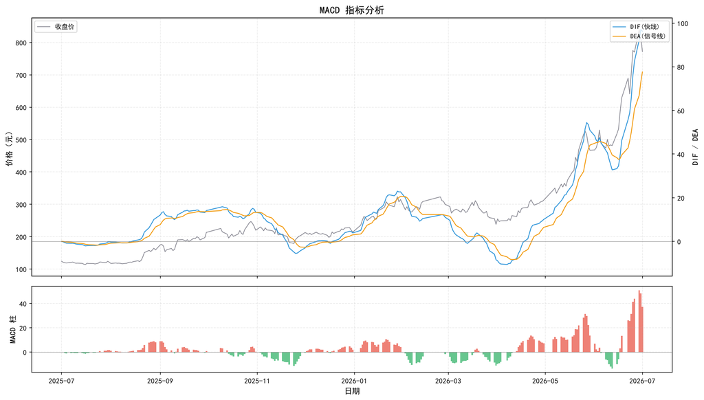

```python
# MACD 计算
ema12 = df['close'].ewm(span=12, adjust=False).mean()
ema26 = df['close'].ewm(span=26, adjust=False).mean()
df['DIF']  = ema12 - ema26
df['DEA']  = df['DIF'].ewm(span=9, adjust=False).mean()
df['MACD'] = 2 * (df['DIF'] - df['DEA'])  # A股惯例: 2倍系数

# MACD 可视化
fig, (ax1, ax2) = plt.subplots(2, 1, figsize=(14, 8), gridspec_kw={'height_ratios': [3, 1]}, sharex=True)

# 上子图：收盘价 + DIF + DEA
ax1.plot(df.index, df['close'], color=DARK, linewidth=1, alpha=0.5, label='收盘价')
ax1_twin = ax1.twinx()
ax1_twin.plot(df.index, df['DIF'], color=BLUE, linewidth=1.2, label='DIF(快线)')
ax1_twin.plot(df.index, df['DEA'], color=ORANGE, linewidth=1.2, label='DEA(信号线)')
ax1_twin.axhline(y=0, color='gray', linewidth=0.5, linestyle='-')
ax1.set_title('MACD 指标分析', fontsize=14, fontweight='bold')
ax1.set_ylabel('价格（元）', fontsize=11)
ax1_twin.set_ylabel('DIF / DEA', fontsize=11)
ax1.legend(loc='upper left', fontsize=9)
ax1_twin.legend(loc='upper right', fontsize=9)
ax1.grid(True, alpha=0.25, linestyle='--')

# 下子图：MACD 柱状图（红正绿负）
macd_colors = [RED if val >= 0 else GREEN for val in df['MACD']]
ax2.bar(df.index, df['MACD'], color=macd_colors, width=1, alpha=0.7)
ax2.axhline(y=0, color='gray', linewidth=0.5)
ax2.set_ylabel('MACD 柱', fontsize=11)
ax2.set_xlabel('日期', fontsize=11)
ax2.grid(True, alpha=0.25, linestyle='--')

plt.tight_layout()
plt.show()
```

## 3. BB（布林带, Bollinger Bands）

布林带利用移动平均和标准差构建价格通道，反映波动范围与趋势边界。

| 要素 | 说明 |
| --- | --- |
| MID（中轨） | MA(close, 20) |
| UPPER（上轨） | MID + 2 × std(close, 20) |
| LOWER（下轨） | MID - 2 × std(close, 20) |

**解读**：触及上轨→超买；触及下轨→超卖；带宽收窄→变盘在即

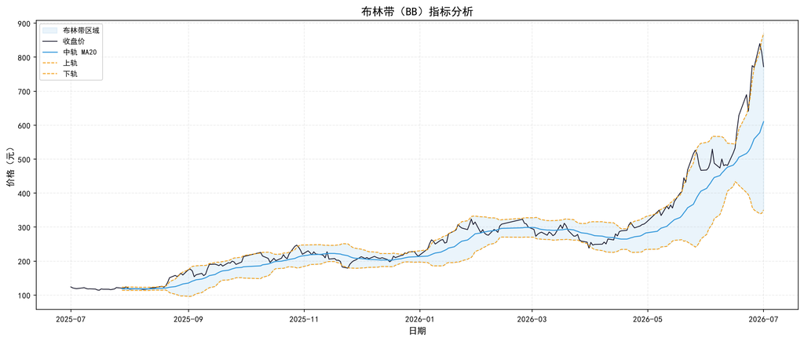

```
当前带宽: 85.17%
平均带宽: 31.25%
```

```python
# BB（布林带）计算
df['BB_MID']   = df['close'].rolling(window=20).mean()
df['BB_UPPER'] = df['BB_MID'] + 2 * df['close'].rolling(window=20).std()
df['BB_LOWER'] = df['BB_MID'] - 2 * df['close'].rolling(window=20).std()
df['BB_WIDTH'] = (df['BB_UPPER'] - df['BB_LOWER']) / df['BB_MID'] * 100  # 带宽(%)

# BB 可视化
fig, ax = plt.subplots(figsize=(14, 6))

# 上下轨填充
ax.fill_between(df.index, df['BB_LOWER'], df['BB_UPPER'], alpha=0.1, color=BLUE, label='布林带区域')

# 收盘价 + 三轨
ax.plot(df.index, df['close'], color=DARK, linewidth=1, label='收盘价')
ax.plot(df.index, df['BB_MID'], color=BLUE, linewidth=1.2, label='中轨 MA20')
ax.plot(df.index, df['BB_UPPER'], color=ORANGE, linewidth=1, linestyle='--', label='上轨')
ax.plot(df.index, df['BB_LOWER'], color=ORANGE, linewidth=1, linestyle='--', label='下轨')

ax.set_title('布林带（BB）指标分析', fontsize=14, fontweight='bold')
ax.set_ylabel('价格（元）', fontsize=11)
ax.set_xlabel('日期', fontsize=11)
ax.legend(loc='upper left', fontsize=9)
ax.grid(True, alpha=0.25, linestyle='--')

plt.tight_layout()
plt.show()

print(f'当前带宽: {df["BB_WIDTH"].iloc[-1]:.2f}%')
print(f'平均带宽: {df["BB_WIDTH"].mean():.2f}%')
```

## 4. RSI（相对强弱指数）

RSI 衡量上涨与下跌动量的相对强度，取值 0~100。

| 要素 | 说明 |
| --- | --- |
| 周期 | 14 日 |
| 平滑 | Wilder 平滑法（ewm alpha=1/14） |
| 超买 | RSI > 70 |
| 超卖 | RSI < 30 |

**信号**：RSI 从 30 以下上穿 30 = 买入；RSI 从 70 以上下穿 70 = 卖出

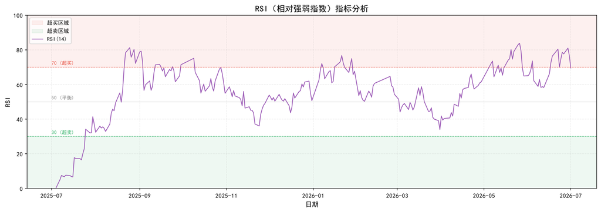

```python
# RSI 计算（Wilder 平滑法）
delta = df['close'].diff()
gain = delta.clip(lower=0)
loss = -delta.clip(upper=0)
avg_gain = gain.ewm(alpha=1/14, adjust=False).mean()
avg_loss = loss.ewm(alpha=1/14, adjust=False).mean()
rs = avg_gain / avg_loss
df['RSI'] = 100 - 100 / (1 + rs)

# RSI 可视化
fig, ax = plt.subplots(figsize=(14, 5))

# 超买/超卖区域填充
ax.axhspan(70, 100, alpha=0.08, color=RED, label='超买区域')
ax.axhspan(0, 30, alpha=0.08, color=GREEN, label='超卖区域')

# RSI 折线
ax.plot(df.index, df['RSI'], color=PURPLE, linewidth=1.2, label='RSI(14)')

# 参考线
ax.axhline(y=70, color=RED, linewidth=0.8, linestyle='--', alpha=0.7)
ax.axhline(y=50, color='gray', linewidth=0.5, linestyle='-', alpha=0.5)
ax.axhline(y=30, color=GREEN, linewidth=0.8, linestyle='--', alpha=0.7)

ax.text(df.index[0], 71, '70 (超买)', fontsize=8, color=RED, va='bottom')
ax.text(df.index[0], 31, '30 (超卖)', fontsize=8, color=GREEN, va='bottom')
ax.text(df.index[0], 51, '50 (平衡)', fontsize=8, color='gray', va='bottom')

ax.set_title('RSI（相对强弱指数）指标分析', fontsize=14, fontweight='bold')
ax.set_ylabel('RSI', fontsize=11)
ax.set_xlabel('日期', fontsize=11)
ax.set_ylim(0, 100)
ax.legend(loc='upper left', fontsize=9)
ax.grid(True, alpha=0.25, linestyle='--')

plt.tight_layout()
plt.show()
```

## 5. ATR（平均真实波幅）

ATR 衡量市场波动程度，反映价格的波动幅度，常用于止损位设定。

[output not shown]

**解读**：ATR上升→波动加剧；ATR下降→市场平静

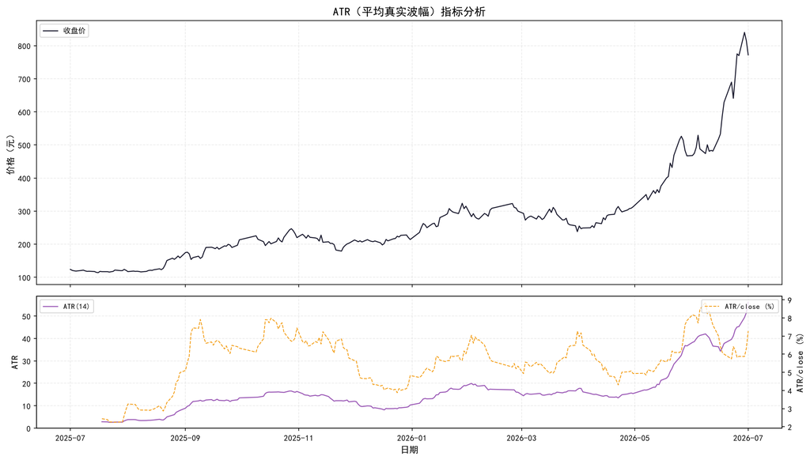

```
当前 ATR: 56.17 元
当前 ATR/close: 7.28%
建议止损距离 (2×ATR): 112.34 元
```

```python
# ATR 计算
tr1 = df['high'] - df['low']
tr2 = (df['high'] - df['close'].shift(1)).abs()
tr3 = (df['low'] - df['close'].shift(1)).abs()
tr = pd.concat([tr1, tr2, tr3], axis=1).max(axis=1)
df['ATR'] = tr.rolling(window=14).mean()
df['ATR_PCT'] = df['ATR'] / df['close'] * 100  # ATR占收盘价百分比

# ATR 可视化
fig, (ax1, ax2) = plt.subplots(2, 1, figsize=(14, 8), gridspec_kw={'height_ratios': [2, 1]}, sharex=True)

# 上子图：收盘价
ax1.plot(df.index, df['close'], color=DARK, linewidth=1.2, label='收盘价')
ax1.set_title('ATR（平均真实波幅）指标分析', fontsize=14, fontweight='bold')
ax1.set_ylabel('价格（元）', fontsize=11)
ax1.legend(loc='upper left', fontsize=9)
ax1.grid(True, alpha=0.25, linestyle='--')

# 下子图：ATR + ATR/close
ax2.plot(df.index, df['ATR'], color=PURPLE, linewidth=1.2, label='ATR(14)')
ax2_twin = ax2.twinx()
ax2_twin.plot(df.index, df['ATR_PCT'], color=ORANGE, linewidth=1, linestyle='--', label='ATR/close (%)')
ax2.set_ylabel('ATR', fontsize=11)
ax2_twin.set_ylabel('ATR/close (%)', fontsize=11)
ax2.set_xlabel('日期', fontsize=11)
ax2.legend(loc='upper left', fontsize=9)
ax2_twin.legend(loc='upper right', fontsize=9)
ax2.grid(True, alpha=0.25, linestyle='--')

plt.tight_layout()
plt.show()

print(f'当前 ATR: {df["ATR"].iloc[-1]:.2f} 元')
print(f'当前 ATR/close: {df["ATR_PCT"].iloc[-1]:.2f}%')
print(f'建议止损距离 (2×ATR): {df["ATR"].iloc[-1] * 2:.2f} 元')
```

## 6. 信号回测

对 MACD 和 RSI 指标生成交易信号，评估 5/10/20 日持有期收益与胜率。

| 信号 | 定义 |
| --- | --- |
| MACD 金叉 | DIF 从下方穿越 DEA 向上 |
| MACD 死叉 | DIF 从上方穿越 DEA 向下 |
| RSI 超卖买入 | RSI 从 30 以下上穿 30 |
| RSI 超买卖出 | RSI 从 70 以上下穿 70 |

```python
# MACD 信号检测
df['DIF_prev'] = df['DIF'].shift(1)
df['DEA_prev'] = df['DEA'].shift(1)
df['MACD_golden'] = (df['DIF'] > df['DEA']) & (df['DIF_prev'] <= df['DEA_prev'])
df['MACD_death']  = (df['DIF'] < df['DEA']) & (df['DIF_prev'] >= df['DEA_prev'])

golden_dates = df.index[df['MACD_golden']]
death_dates  = df.index[df['MACD_death']]

print(f'MACD 金叉信号: {len(golden_dates)} 次')
for d in golden_dates:
    print(f'  {d.date()}  DIF={df.loc[d, "DIF"]:.2f}  DEA={df.loc[d, "DEA"]:.2f}  收盘={df.loc[d, "close"]:.2f}')
print(f'\nMACD 死叉信号: {len(death_dates)} 次')
for d in death_dates:
    print(f'  {d.date()}  DIF={df.loc[d, "DIF"]:.2f}  DEA={df.loc[d, "DEA"]:.2f}  收盘={df.loc[d, "close"]:.2f}')
```

```
MACD 金叉信号: 10 次
  2025-07-24  DIF=-1.68  DEA=-1.70  收盘=117.89
  2025-08-12  DIF=-0.50  DEA=-0.63  收盘=120.47
  2025-09-11  DIF=10.74  DEA=10.57  收盘=177.42
  2025-09-30  DIF=14.13  DEA=13.68  收盘=213.30
  2025-10-27  DIF=12.71  DEA=11.87  收盘=243.19
  2025-12-02  DIF=-2.14  DEA=-2.57  收盘=210.50
  2025-12-18  DIF=-0.09  DEA=-0.39  收盘=214.45
  2026-03-18  DIF=3.20  DEA=2.24  收盘=311.25
  2026-04-13  DIF=-7.88  DEA=-8.22  收盘=262.14
  2026-06-17  DIF=39.43  DEA=37.95  收盘=586.04

MACD 死叉信号: 10 次
  2025-07-02  DIF=-0.24  DEA=-0.05  收盘=120.98
  2025-08-08  DIF=-0.73  DEA=-0.65  收盘=116.40
  2025-09-09  DIF=10.46  DEA=10.67  收盘=157.15
  2025-09-26  DIF=13.45  DEA=13.66  收盘=190.21
  2025-10-14  DIF=13.69  DEA=14.42  收盘=196.00
  2025-11-03  DIF=12.89  DEA=13.22  收盘=230.10
  2025-12-16  DIF=-0.63  DEA=-0.36  收盘=197.86
  2026-02-02  DIF=19.97  DEA=20.51  收盘=283.39
  2026-03-23  DIF=1.45  DEA=2.46  收盘=273.35
  2026-06-05  DIF=45.20  DEA=45.66  收盘=488.00
```

```python
# MACD 信号回测评估
def backtest_signal(signal_dates, hold_days, is_short=False):
    """计算信号触发后持有 N 日的收益。"""
    results = []
    for d in signal_dates:
        idx = df.index.get_loc(d)
        if idx + hold_days >= len(df):
            continue  # 不足持有期，跳过
        entry = df['close'].iloc[idx]
        exit_ = df['close'].iloc[idx + hold_days]
        if is_short:
            ret = (entry - exit_) / entry * 100  # 做空收益
        else:
            ret = (exit_ - entry) / entry * 100  # 做多收益
        results.append(ret)
    if not results:
        return 0, 0, 0
    win_rate = sum(1 for r in results if r > 0) / len(results) * 100
    avg_ret = np.mean(results)
    return len(results), win_rate, avg_ret

# 评估 MACD 信号
hold_periods = [5, 10, 20]
macd_results = {}
for label, dates, is_short in [('MACD金叉', golden_dates, False), ('MACD死叉', death_dates, True)]:
    row = {}
    for h in hold_periods:
        n, wr, ar = backtest_signal(dates, h, is_short)
        row[f'{h}日信号数'] = n
        row[f'{h}日胜率(%)'] = round(wr, 1)
        row[f'{h}日均收益(%)'] = round(ar, 2)
    macd_results[label] = row

macd_df = pd.DataFrame(macd_results).T
macd_df
```

|  | 5日信号数 | 5日胜率(%) | 5日均收益(%) | 10日信号数 | 10日胜率(%) | 10日均收益(%) | 20日信号数 | 20日胜率(%) | 20日均收益(%) |
| --- | --- | --- | --- | --- | --- | --- | --- | --- | --- |
| MACD金叉 | 10.0 | 70.0 | 3.83 | 9.0 | 44.4 | 3.30 | 9.0 | 77.8 | 11.49 |
| MACD死叉 | 10.0 | 40.0 | -4.64 | 10.0 | 30.0 | -13.12 | 9.0 | 11.1 | -14.88 |

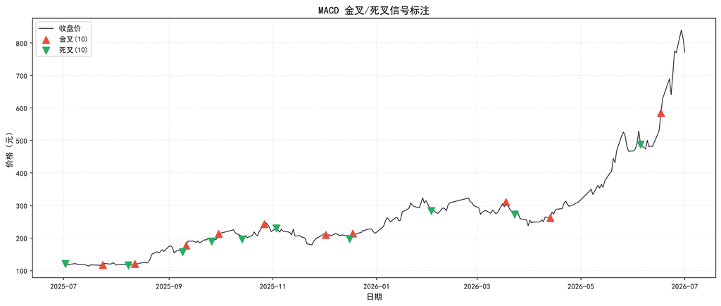

```python
# MACD 信号可视化：价格图标注金叉/死叉
fig, ax = plt.subplots(figsize=(14, 6))

# 收盘价
ax.plot(df.index, df['close'], color=DARK, linewidth=1, label='收盘价')

# 金叉信号 ▲
if len(golden_dates) > 0:
    ax.scatter(golden_dates, df.loc[golden_dates, 'close'],
              marker='^', color=RED, s=100, zorder=5, label=f'金叉({len(golden_dates)})')

# 死叉信号 ▼
if len(death_dates) > 0:
    ax.scatter(death_dates, df.loc[death_dates, 'close'],
              marker='v', color=GREEN, s=100, zorder=5, label=f'死叉({len(death_dates)})')

ax.set_title('MACD 金叉/死叉信号标注', fontsize=14, fontweight='bold')
ax.set_ylabel('价格（元）', fontsize=11)
ax.set_xlabel('日期', fontsize=11)
ax.legend(loc='upper left', fontsize=10)
ax.grid(True, alpha=0.25, linestyle='--')

plt.tight_layout()
plt.show()
```

```python
# RSI 信号检测
df['RSI_prev'] = df['RSI'].shift(1)
df['RSI_oversold']   = (df['RSI_prev'] < 30) & (df['RSI'] >= 30)   # 超卖买入
df['RSI_overbought'] = (df['RSI_prev'] > 70) & (df['RSI'] <= 70)   # 超买卖出

oversold_dates   = df.index[df['RSI_oversold']]
overbought_dates = df.index[df['RSI_overbought']]

print(f'RSI 超卖买入信号: {len(oversold_dates)} 次')
for d in oversold_dates:
    print(f'  {d.date()}  RSI={df.loc[d, "RSI"]:.1f}  收盘={df.loc[d, "close"]:.2f}')
print(f'\nRSI 超买卖出信号: {len(overbought_dates)} 次')
for d in overbought_dates:
    print(f'  {d.date()}  RSI={df.loc[d, "RSI"]:.1f}  收盘={df.loc[d, "close"]:.2f}')
```

```
RSI 超卖买入信号: 1 次
  2025-07-25  RSI=34.2  收盘=121.94

RSI 超买卖出信号: 13 次
  2025-09-04  RSI=56.6  收盘=153.98
  2025-09-17  RSI=67.8  收盘=186.60
  2025-09-25  RSI=68.0  收盘=197.41
  2025-10-10  RSI=67.1  收盘=215.02
  2026-01-08  RSI=69.3  收盘=258.75
  2026-01-23  RSI=69.9  收盘=297.25
  2026-01-29  RSI=65.7  收盘=307.50
  2026-05-08  RSI=64.4  收盘=334.10
  2026-05-12  RSI=67.0  收盘=353.55
  2026-05-28  RSI=69.4  收盘=483.00
  2026-06-05  RSI=62.2  收盘=488.00
  2026-06-23  RSI=69.9  收盘=640.99
  2026-07-01  RSI=69.5  收盘=772.01
```

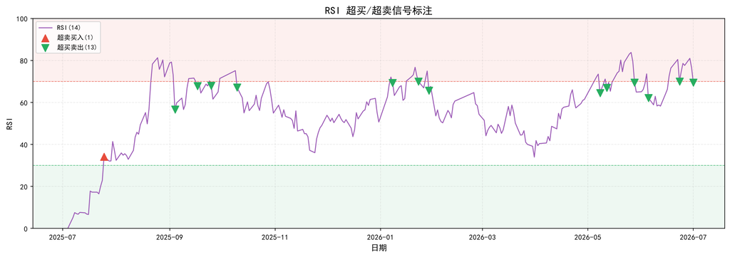

```python
# RSI 信号回测评估 + 可视化
rsi_results = {}
for label, dates, is_short in [('RSI超卖买入', oversold_dates, False), ('RSI超买卖出', overbought_dates, True)]:
    row = {}
    for h in hold_periods:
        n, wr, ar = backtest_signal(dates, h, is_short)
        row[f'{h}日信号数'] = n
        row[f'{h}日胜率(%)'] = round(wr, 1)
        row[f'{h}日均收益(%)'] = round(ar, 2)
    rsi_results[label] = row

# 可视化：RSI + 信号标注
fig, ax = plt.subplots(figsize=(14, 5))

ax.axhspan(70, 100, alpha=0.08, color=RED)
ax.axhspan(0, 30, alpha=0.08, color=GREEN)
ax.plot(df.index, df['RSI'], color=PURPLE, linewidth=1.2, label='RSI(14)')
ax.axhline(y=70, color=RED, linewidth=0.8, linestyle='--', alpha=0.7)
ax.axhline(y=30, color=GREEN, linewidth=0.8, linestyle='--', alpha=0.7)

if len(oversold_dates) > 0:
    ax.scatter(oversold_dates, df.loc[oversold_dates, 'RSI'],
              marker='^', color=RED, s=100, zorder=5, label=f'超卖买入({len(oversold_dates)})')
if len(overbought_dates) > 0:
    ax.scatter(overbought_dates, df.loc[overbought_dates, 'RSI'],
              marker='v', color=GREEN, s=100, zorder=5, label=f'超买卖出({len(overbought_dates)})')

ax.set_title('RSI 超买/超卖信号标注', fontsize=14, fontweight='bold')
ax.set_ylabel('RSI', fontsize=11)
ax.set_xlabel('日期', fontsize=11)
ax.set_ylim(0, 100)
ax.legend(loc='upper left', fontsize=9)
ax.grid(True, alpha=0.25, linestyle='--')

plt.tight_layout()
plt.show()
```

```python
# 回测汇总表
summary = pd.concat([macd_df, pd.DataFrame(rsi_results).T])
summary.columns = pd.MultiIndex.from_tuples([
    ('5日', '信号数'), ('5日', '胜率(%)'), ('5日', '均收益(%)'),
    ('10日', '信号数'), ('10日', '胜率(%)'), ('10日', '均收益(%)'),
    ('20日', '信号数'), ('20日', '胜率(%)'), ('20日', '均收益(%)'),
])
print('信号回测汇总表')
print('=' * 80)
summary
```

```
信号回测汇总表
================================================================================
```

|  | 5日 信号数 | 5日 胜率(%) | 5日 均收益(%) | 10日 信号数 | 10日 胜率(%) | 10日 均收益(%) | 20日 信号数 | 20日 胜率(%) | 20日 均收益(%) |
| --- | --- | --- | --- | --- | --- | --- | --- | --- | --- |
| MACD金叉 | 10.0 | 70.0 | 3.83 | 9.0 | 44.4 | 3.30 | 9.0 | 77.8 | 11.49 |
| MACD死叉 | 10.0 | 40.0 | -4.64 | 10.0 | 30.0 | -13.12 | 9.0 | 11.1 | -14.88 |
| RSI超卖买入 | 1.0 | 0.0 | -3.80 | 1.0 | 0.0 | -4.54 | 1.0 | 100.0 | 23.73 |
| RSI超买卖出 | 12.0 | 33.3 | -6.81 | 11.0 | 18.2 | -17.11 | 10.0 | 20.0 | -21.04 |

## 7. 综合分析

将四项指标交叉对比，从趋势、波动、动量三个维度综合评估兆易创新的价格行为特征。

| 维度 | 指标 | 关注点 |
| --- | --- | --- |
| 趋势 | MACD | DIF/DEA 零轴位置、金叉死叉频率 |
| 趋势/波动 | BB | 带宽变化、轨道触及频率 |
| 动量 | RSI | 超买超卖频率、多空平衡偏移 |
| 波动率 | ATR | 波动幅度变化、相对波动率水平 |

```
findfont: Failed to find font weight bold, now using 400.
```

```
findfont: Failed to find font weight bold, now using 400.
```

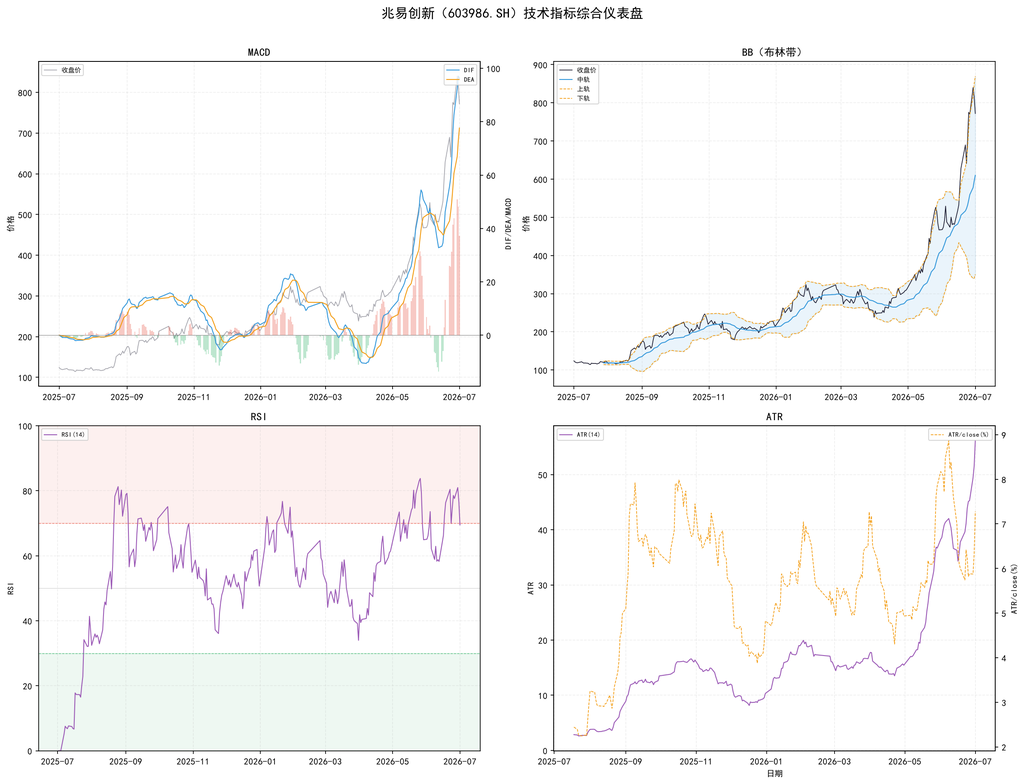

```python
# 综合仪表盘：2×2 多子图
fig, axes = plt.subplots(2, 2, figsize=(16, 12))

# (1) MACD
ax = axes[0, 0]
ax.plot(df.index, df['close'], color=DARK, linewidth=0.8, alpha=0.4, label='收盘价')
ax_twin = ax.twinx()
ax_twin.plot(df.index, df['DIF'], color=BLUE, linewidth=1, label='DIF')
ax_twin.plot(df.index, df['DEA'], color=ORANGE, linewidth=1, label='DEA')
ax_twin.axhline(y=0, color='gray', linewidth=0.5)
macd_colors = [RED if v >= 0 else GREEN for v in df['MACD']]
ax_twin.bar(df.index, df['MACD'], color=macd_colors, width=1, alpha=0.3)
ax.set_title('MACD', fontsize=12, fontweight='bold')
ax.set_ylabel('价格', fontsize=9)
ax_twin.set_ylabel('DIF/DEA/MACD', fontsize=9)
ax.legend(loc='upper left', fontsize=7)
ax_twin.legend(loc='upper right', fontsize=7)
ax.grid(True, alpha=0.2, linestyle='--')

# (2) BB
ax = axes[0, 1]
ax.fill_between(df.index, df['BB_LOWER'], df['BB_UPPER'], alpha=0.1, color=BLUE)
ax.plot(df.index, df['close'], color=DARK, linewidth=0.8, label='收盘价')
ax.plot(df.index, df['BB_MID'], color=BLUE, linewidth=1, label='中轨')
ax.plot(df.index, df['BB_UPPER'], color=ORANGE, linewidth=0.8, linestyle='--', label='上轨')
ax.plot(df.index, df['BB_LOWER'], color=ORANGE, linewidth=0.8, linestyle='--', label='下轨')
ax.set_title('BB（布林带）', fontsize=12, fontweight='bold')
ax.set_ylabel('价格', fontsize=9)
ax.legend(loc='upper left', fontsize=7)
ax.grid(True, alpha=0.2, linestyle='--')

# (3) RSI
ax = axes[1, 0]
ax.axhspan(70, 100, alpha=0.08, color=RED)
ax.axhspan(0, 30, alpha=0.08, color=GREEN)
ax.plot(df.index, df['RSI'], color=PURPLE, linewidth=1, label='RSI(14)')
ax.axhline(y=70, color=RED, linewidth=0.7, linestyle='--', alpha=0.7)
ax.axhline(y=30, color=GREEN, linewidth=0.7, linestyle='--', alpha=0.7)
ax.axhline(y=50, color='gray', linewidth=0.4, alpha=0.5)
ax.set_title('RSI', fontsize=12, fontweight='bold')
ax.set_ylabel('RSI', fontsize=9)
ax.set_ylim(0, 100)
ax.legend(loc='upper left', fontsize=7)
ax.grid(True, alpha=0.2, linestyle='--')

# (4) ATR
ax = axes[1, 1]
ax.plot(df.index, df['ATR'], color=PURPLE, linewidth=1, label='ATR(14)')
ax_twin = ax.twinx()
ax_twin.plot(df.index, df['ATR_PCT'], color=ORANGE, linewidth=0.8, linestyle='--', label='ATR/close(%)')
ax.set_title('ATR', fontsize=12, fontweight='bold')
ax.set_ylabel('ATR', fontsize=9)
ax_twin.set_ylabel('ATR/close(%)', fontsize=9)
ax.set_xlabel('日期', fontsize=9)
ax.legend(loc='upper left', fontsize=7)
ax_twin.legend(loc='upper right', fontsize=7)
ax.grid(True, alpha=0.2, linestyle='--')

plt.suptitle('兆易创新（603986.SH）技术指标综合仪表盘', fontsize=15, fontweight='bold', y=1.01)
plt.tight_layout()
plt.show()
```

## 免责声明

本 Notebook 仅供学习和研究使用，不构成任何投资建议。技术指标分析存在局限性，过往表现不代表未来收益。投资有风险，入市需谨慎。

> **TASK2 技术指标分析实验室** | 兆易创新 603986.SH | 数据区间 2025-07-01 ~ 2026-07-01